# Final Project Data Analysis for Business -

# STATBIZ

Group members:

- Michele Turco (285251)
- Giulio Presaghi(287611)
- Edoardo Brown (281671)
- Irene Benvenuti (288521)

## TASK 1

The dataset under analysis is the “Telecom Churn” dataset, which includes data about a US Telecom company. Our primary goal is to predict customer churn to help the company take proactive steps to retain clients. In a real-world context, understanding this target variable is crucial for businesses aiming to improve customer retention. ‘Churn’ signifies customers who have ended their relationship with the company, while ‘Not churn’ indicates those who continue to engage with the company’s services or products. By identifying customers at high risk of leaving, the company can strategically offer promotions and incentives to enhance customer retention and reduce churn rates.

### DATASET DESCRIPTION

#### Importing the dataset

The dataset consists of 3333 observations with 20 variables related to telecom customer attributes, such as state, account length, service usage details, and whether the customer churned or not. In particular, we can see that there are 15 numerical variables and 5 categorical variables.

```
## 'data.frame':    3333 obs. of  20 variables:
##  $ State                 : Factor w/ 51 levels "AK","AL","AR",..: 17 36 32 36 37 2 20 25 19 50 ...
##  $ Account.length        : num  128 107 137 84 75 118 121 147 117 141 ...
##  $ Area.code             : Factor w/ 3 levels "408","415","510": 2 2 2 1 2 3 3 2 1 2 ...
##  $ International.plan    : Factor w/ 2 levels "No","Yes": 1 1 1 2 2 2 1 2 1 2 ...
##  $ Voice.mail.plan       : Factor w/ 2 levels "No","Yes": 2 2 1 1 1 1 2 1 1 2 ...
##  $ Number.vmail.messages : num  25 26 0 0 0 0 24 0 0 37 ...
##  $ Total.day.minutes     : num  265 162 243 299 167 ...
##  $ Total.day.calls       : num  110 123 114 71 113 98 88 79 97 84 ...
##  $ Total.day.charge      : num  45.1 27.5 41.4 50.9 28.3 ...
##  $ Total.eve.minutes     : num  197.4 195.5 121.2 61.9 148.3 ...
##  $ Total.eve.calls       : num  99 103 110 88 122 101 108 94 80 111 ...
##  $ Total.eve.charge      : num  16.78 16.62 10.3 5.26 12.61 ...
##  $ Total.night.minutes   : num  245 254 163 197 187 ...
##  $ Total.night.calls     : num  91 103 104 89 121 118 118 96 90 97 ...
##  $ Total.night.charge    : num  11.01 11.45 7.32 8.86 8.41 ...
##  $ Total.intl.minutes    : num  10 13.7 12.2 6.6 10.1 6.3 7.5 7.1 8.7 11.2 ...
##  $ Total.intl.calls      : num  3 3 5 7 3 6 7 6 4 5 ...
##  $ Total.intl.charge     : num  2.7 3.7 3.29 1.78 2.73 1.7 2.03 1.92 2.35 3.02 ...
##  $ Customer.service.calls: num  1 1 0 2 3 0 3 0 1 0 ...
##  $ Churn                 : Factor w/ 2 levels "False","True": 1 1 1 1 1 1 1 1 1 1 ...
```

#### Cleaning the dataset

The dataset does not contain any missing value and hence this is not an issue that need to be addressed.

```
## Rows with NA before preprocessing: 0
```

In addition, the dataset does not present any duplicated value and consequently the issue does not need to be addressed.

```
## There are 0 duplicates rows in the Dataset before preprocessing
```

### EDA

Exploratory Data Analysis (EDA) is a crucial step in understanding the underlying patterns and relationships within the dataset. Through this analysis, we aim to gain insights that will inform the subsequent steps of data preprocessing and model building. We will consider categorical variables (excluding the state variable because of its nature) and numerical variables, for which we computed a correlation matrix.

#### Target variable distribution

In this section we consider our target variable “Churn” and its distribution. To do this, we will plot both a histogram to visualize the number of observations for each class and a pie chart to better understand their proportions in the dataset.

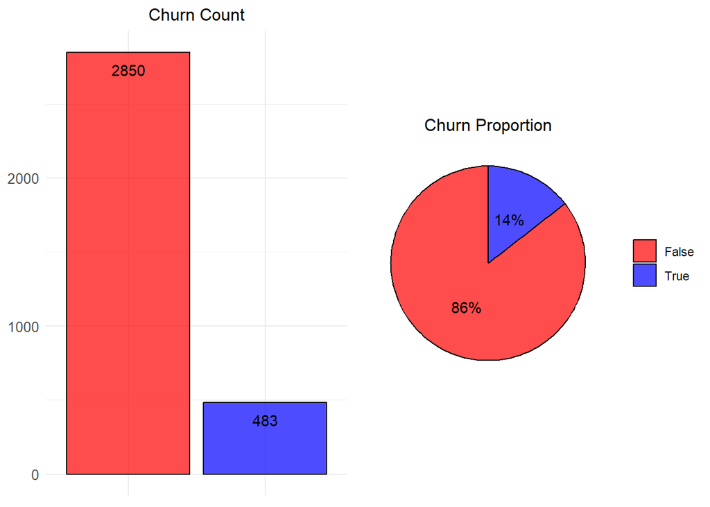

The histogram on the left shows that there are 2850 customers who did not churn (False) and 483 customers who did churn (True). The pie chart on the right indicates that 86% of customers did not churn, while 14% did churn. This highlights an significance imbalance in the dataset, with an higher number of customers not churning compared to those who do.

#### Categorical variables

In this section we analyze the categorical variables in our dataset. In order to get more insightful results in the analysis of the distribution of categorical variables, we firstly plot the proportion of each class in a pie chart (as we did before with our target variable).

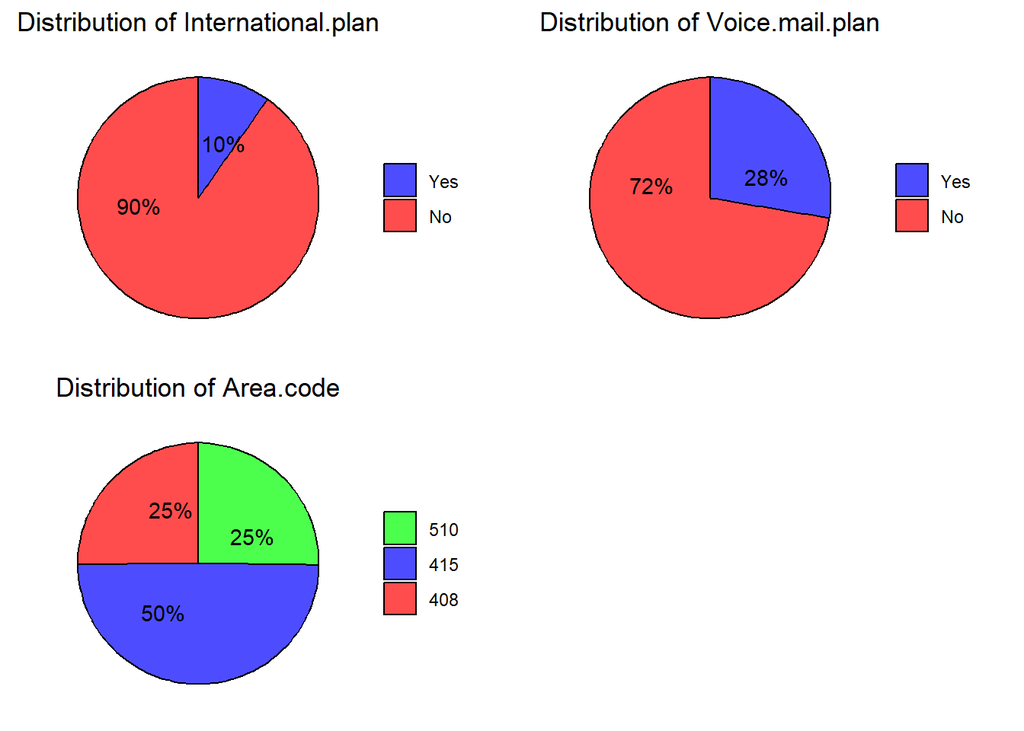

The pie chart shows that 90% of the customers do not have an international plan, while only 10% have opted for one. This indicates that the majority of customers do not use international calling services. In addition, 72% of the customers do not have a voice mail plan, whereas 28% have subscribed to this service. This suggests that a significant portion of the customer base does not utilize voice mail services. The pie chart shows also the distribution of customers across three area codes: 408, 415, and 510. The distribution is relatively balanced, with 50% of customers having area code 415, and the remaining 50% evenly split between area codes 408 and 510 (25% each). This indicates that the customer base is fairly evenly distributed across these three regions.

Furthermore, we wanted to highlight the distribution of customer churn across the three categorical variables with an histogram in which the bars represent the counts of customers who churned (True) and did not churn (False) for each category.

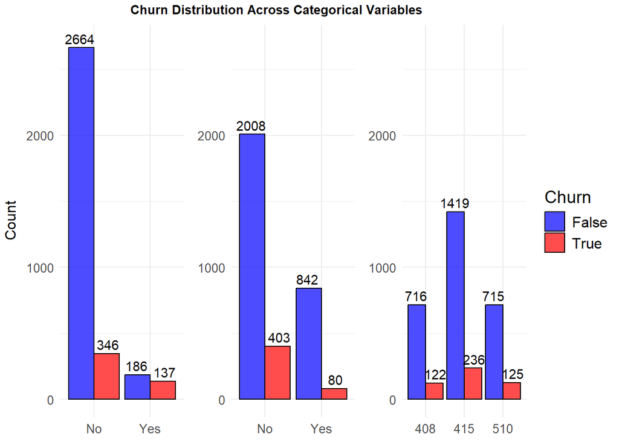

The majority of customers without an international plan (2664) did not churn, whereas 346 customers did churn. For customers with an international plan, there are 186 non-churners compared to 137 churners.

Among customers without a voice mail plan, 2008 did not churn, while 403 churned. For customers with a voice mail plan, 842 did not churn and 80 churned.

The churn distribution is somewhat balanced across area codes, with 408 and 510 having slightly higher churn rates (122 and 125 churners respectively) compared to area code 415 (236 churners). The number of non-churners is highest in area code 415 (1419) compared to 408 (716) and 510 (715).

What is particularly interesting is that the proportion of churn is higher among customers with an international plan compared to those without. In fact, almost half of the customers who were subscribed to the International plan have churned, suggesting that this factor may heavily influence customer decisions. However, to draw any definitive conclusions, we need to perform a more in-depth analysis.

##### Chi-Square Test with International Plan and Churn

To statistically interpret the hypothesis stated above, we performed a Chi-Square Test on the two variables. The Chi-Square test is a statistical method used to determine if there is a significant association between two categorical variables. It compares the observed frequencies in each category to the expected frequencies under the null hypothesis, which posits that the variables are independent.

- H0 (Null Hypothesis): There is no association between the two categorical variables; they are independent.
- H1 (Alternative Hypothesis): There is an association between the two categorical variables; they are not independent.

```
## [1] "Chi Square Test on International Plan and Churn"
```

```
##
##  Pearson's Chi-squared test with Yates' continuity correction
##
## data:  contingency_table
## X-squared = 222.57, df = 1, p-value < 2.2e-16
```

X-squared = 222.57 is the test statistic value, which measures the discrepancy between the observed and expected frequencies. The extremely small p-value (< 2.2e-16) indicates that the probability of observing such a discrepancy by random chance is very low. Since the p-value is much smaller than the conventional significance level (e.g., 0.05), the null hypothesis is rejected, suggesting that there is a statistically significant association between the two categorical variables in the dataset. In other words, the data provides strong evidence that the variables are not independent and that there is a significant relationship between them.

##### State variable

Due to its particularly high number of levels (51), we decided to analyze this variable differently from other categorical variables. A “classic” plot would not have been as insightful. Therefore, we plotted the churn rate across USA states directly on a map, (after ensuring rthat observations were balanced between states). This approach provides a clearer understanding of whether the variable distribution varies by state.

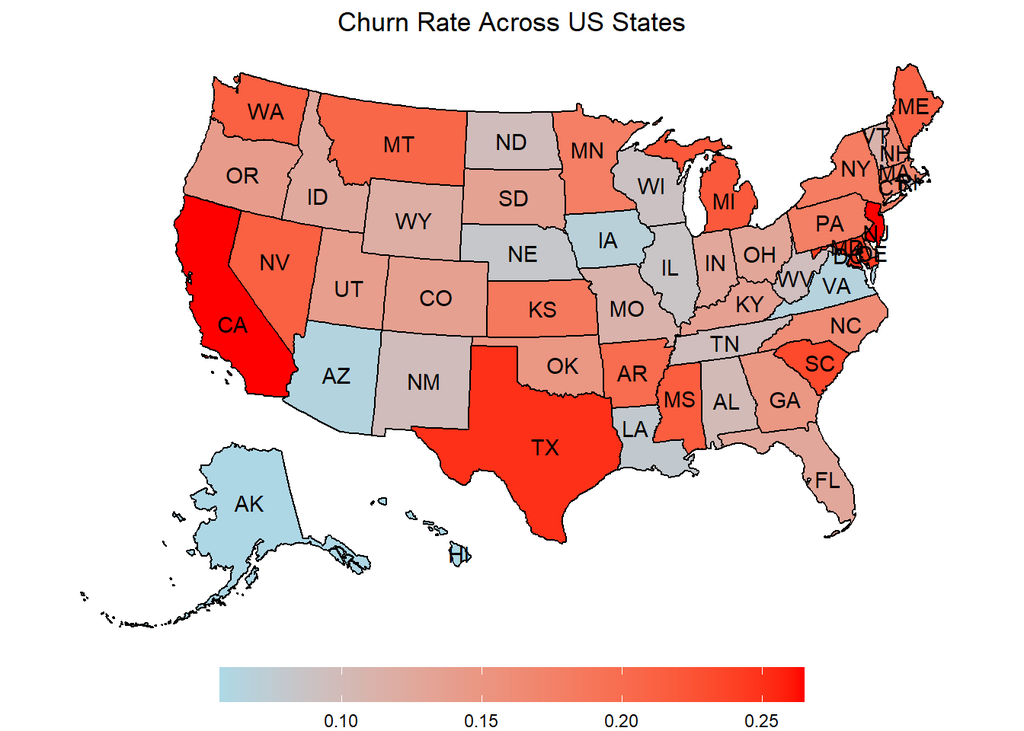

The plot indicates that the churn rate distribution does vary significantly across states. For example, California (CA) and Texas (TX) exhibit higher churn rates, indicated by the deep red shading (25%, as shown in the legend), suggesting that a substantial proportion of customers in these states are leaving the service. In contrast, states like Alaska (AK) and Iowa (IA), shaded in blue, have much lower churn rates (<10%), indicating better customer retention.

Reference -> https://youtu.be/Hi3fXGRBCMA?si=LfPkHpsmNk6cQ_hZ

##### Chi squared test on State and Churn

We decided to perform the Chi-Square test in order to have a more accurate insight.

```
## [1] "Chi Square Test on State and Churn"
```

```
##
##  Pearson's Chi-squared test
##
## data:  contingency_table
## X-squared = 83.044, df = 50, p-value = 0.002296
```

Since the p-value is less than 0.05 also in this case, we reject the null hypothesis (H0) that the two categorical variables are independent. This indicates a significant association between the variables. However, while both tests reject the null hypothesis, the first test shows a more pronounced discrepancy between observed and expected frequencies with a simpler model, while the second test shows a significant association in a more complex scenario, shown by the degrees of freedom df = 50 (higher number of categories for the state variable).

#### Numerical variables

In this section, we perform Exploratory Data Analysis (EDA) on numerical variables to understand their distributions, identify patterns, and detect any anomalies. This analysis will provide key insights and inform subsequent data preprocessing and modeling steps.

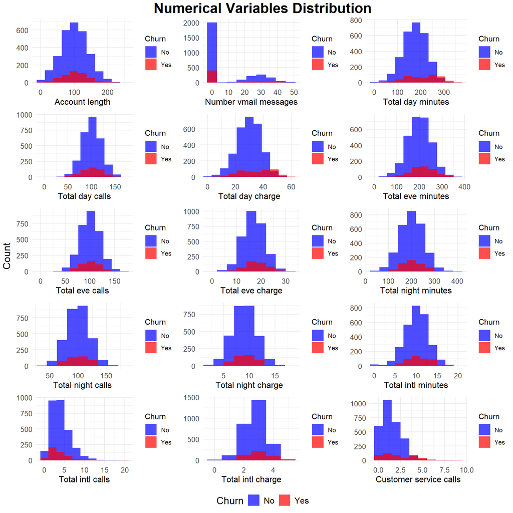

Across most variables, the proportion of customers who churn (red) is relatively small compared to those who do not churn (blue), consistent with the overall churn rate in the dataset. For Customer service calls, the churn proportion noticeably increases with higher values, suggesting that frequent contact with customer service may indicate dissatisfaction leading to churn. In Total day minutes, customers with very high usage show a slightly higher churn rate, potentially due to issues related to usage limits or service quality.

##### ANOVA test on Total Day Minutes and Churn

The ANOVA (Analysis of Variance) test between a categorical and a continuous variable is a statistical method used to determine if there are significant differences in the means of the continuous variable across the levels of the categorical variable. It tests the null hypothesis that the means are equal across all groups against the alternative hypothesis that at least one group mean is different.

In the first place, we better represent the data with boxplots.

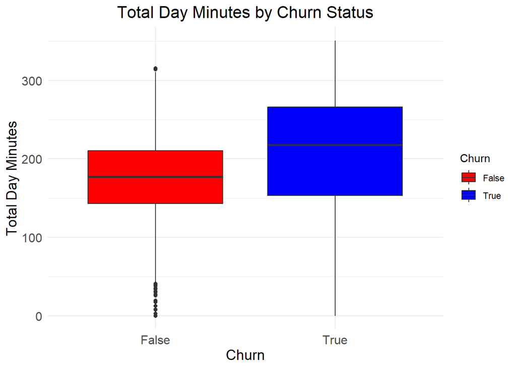

```
## [1] "ANOVA Test on Total day minutes and Churn"
```

```
##               Df  Sum Sq Mean Sq F value Pr(>F)
## Churn          1  416030  416030   146.4 <2e-16 ***
## Residuals   3331 9469003    2843
## ---
## Signif. codes:  0 '***' 0.001 '**' 0.01 '*' 0.05 '.' 0.1 ' ' 1
```

The ANOVA test shows a significant effect of Churn on the continuous variable analyzed, with a very high F value (146.4) and a p-value < 2e-16. This indicates that the means of Total day minutes differ significantly between the churn and non-churn groups.

##### ANOVA test on Customer Service Calls and Churn

We repeat the same test for Customer Service Calls

```
## [1] "ANOVA Test on Customer Service Calls and Churn"
```

```
##               Df Sum Sq Mean Sq F value Pr(>F)
## Churn          1    251  251.27   151.8 <2e-16 ***
## Residuals   3331   5515    1.66
## ---
## Signif. codes:  0 '***' 0.001 '**' 0.01 '*' 0.05 '.' 0.1 ' ' 1
```

In this case, the ANOVA results show a highly significant effect of the churn status on the continuous variable, with a very low p-value (< 2e-16). This indicates a significant difference in the means of the continuous variable between customers who churn and those who do not. The high F value (151.8) suggests that the churn status explains a substantial portion of the variability in the continuous variable, more so than indicated by the previous ANOVA results.

#### Correlation Analysis

In this section, we measure the correlation between numerical variables. Correlation is a statistical measure that describes the extent to which two variables change together. It is particularly relevant since collinearity, or multicollinearity, occurs when two or more predictor variables in a dataset are highly correlated. This means that these variables share similar information and move together in a predictable way. We will deal later with this aspect.

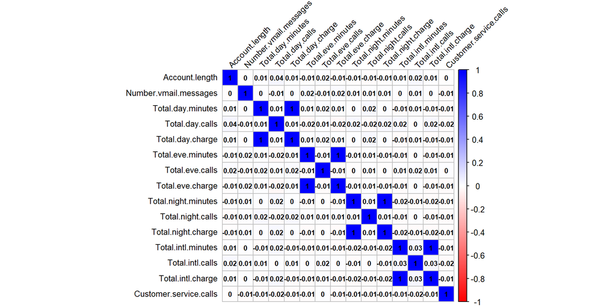

### PREPROCESSING

#### Dealing with collinearity

As stated during our EDA, considering collinearity and correlations is crucial in classification problems because highly correlated variables can lead to redundancy and affect the model’s performance. When predictors are highly correlated, they may provide overlapping information, which can complicate the model’s ability to learn effectively and can also inflate the importance of certain features. By identifying and addressing these correlations, we can simplify the model, improve its interpretability, and enhance its predictive performance. Consequently, we proceed in removing variables that are highly correlated to others.

```
## Dropped Total.day.charge
## Dropped Total.eve.charge
## Dropped Total.night.charge
## Dropped Total.intl.charge
```

#### Dealing with categorical variable with too many levels

Having a categorical variable with too many levels in the dataset can increase model complexity, lead to overfitting, reduce computational efficiency, and make the model harder to interpret. In our case, the variable State has too many levels and hence needs to be preprocessed to reduce its dimension. After some research, we found that since 1950, the United States Census Bureau (a principal agency of the U.S. Federal Statistical System, responsible for producing data about the American people) defines four statistical regions: Northeast, West, South, and Midwest. This division is widely used for data collection and analysis and fits our case particularly well as it reduces the levels of the variable from 51 to 4, a significant improvement.

Reference -> https://en.wikipedia.org/wiki/List_of_regions_of_the_United_States

```
## Distinct values for the Region variable: Midwest Northeast South West
```

### SPLITTING AND SCALING DATASET

In the first place, we decided to split the dataset into a training set (75% of the data) and a test set (25% of the data). We examined the distribution of the target variable Churn for the original, training, and test sets, displaying the counts and proportions of churned vs. non-churned customers.

```
## Distribution of the target variable in the original set:
```

```
## Counts:
```

```
##
## False  True
##  2850   483
```

```
## Proportions:
```

```
##
##     False      True
## 0.8550855 0.1449145
```

```
## Distribution of the target variable in the train set:
```

```
## Counts:
```

```
##
## False  True
##  2130   369
```

```
## Proportions:
```

```
##
##     False      True
## 0.8523409 0.1476591
```

```
## Distribution of the target variable in the validation set:
```

```
## Counts:
```

```
##
## False  True
##   720   114
```

```
## Proportions:
```

```
##
##     False      True
## 0.8633094 0.1366906
```

To address the unbalanced dataset, we created a training set using oversampling. Oversampling is important as it provides the model with enough examples of the minority class, helping it learn the characteristics of both classes more accurately. This improves the model’s ability to predict minority class instances, which is crucial in our analysis since predicting customer churn is a key objective for Telecom.

We also attempted undersampling, as suggested in the R reference script of the project. However, the results were quite poor due to the reduced number of data points available for training, which limited the model’s learning capability. Consequently, we did not report our findings using this technique.

```
## Distribution of the target variable in the oversampled test set:
```

```
## Counts:
```

```
##
## False  True
##  2130  2130
```

```
## Proportions:
```

```
##
## False  True
##   0.5   0.5
```

Afterwards, we scaled the numerical variables in the training and oversampled datasets using their respective means and standard deviations. Scaling ensures that all numerical features contribute equally to the model’s learning process, preventing features with larger ranges from dominating the model’s behavior. We also scaled the test set using the means and standard deviations from the original training set, ensuring consistency in data preprocessing.

### LOW DIMENSIONAL MODEL ANALYSIS

Before proceeding to the full model aimed at providing the best result, we focus on some lower-dimensional models by considering only a few variables. This approach helps investigate interesting relationships within the data, offering clearer insights and interpretations

#### Effects of Total day minutes and International Plan on Customer Churn

As a first analysis, we fit a logistic regression model to evaluate the effects of Total day minutes and International Plan on Customer Churn, considering the unbalanced dataset.

```r
set.seed(1)
model_international_minutes = glm(Churn ~ Total.day.minutes * International.plan,
                           family = binomial(link = "logit"),
                           data = test_data)
# View model summary
summary(model_international_minutes)
```

```
##
## Call:
## glm(formula = Churn ~ Total.day.minutes * International.plan,
##     family = binomial(link = "logit"), data = test_data)
##
## Deviance Residuals:
##     Min       1Q   Median       3Q      Max
## -1.1284  -0.5372  -0.4000  -0.2792   3.1448
##
## Coefficients:
##                                          Estimate Std. Error z value Pr(>|z|)
## (Intercept)                             -4.937732   0.486252 -10.155  < 2e-16
## Total.day.minutes                        0.014817   0.002263   6.547 5.86e-11
## International.planYes                    4.231389   1.045725   4.046 5.20e-05
## Total.day.minutes:International.planYes -0.012772   0.005354  -2.385   0.0171
##
## (Intercept)                             ***
## Total.day.minutes                       ***
## International.planYes                   ***
## Total.day.minutes:International.planYes *
## ---
## Signif. codes:  0 '***' 0.001 '**' 0.01 '*' 0.05 '.' 0.1 ' ' 1
##
## (Dispersion parameter for binomial family taken to be 1)
##
##     Null deviance: 665.38  on 833  degrees of freedom
## Residual deviance: 581.71  on 830  degrees of freedom
## AIC: 589.71
##
## Number of Fisher Scoring iterations: 5
```

We proceed by plotting the computed probabilities.

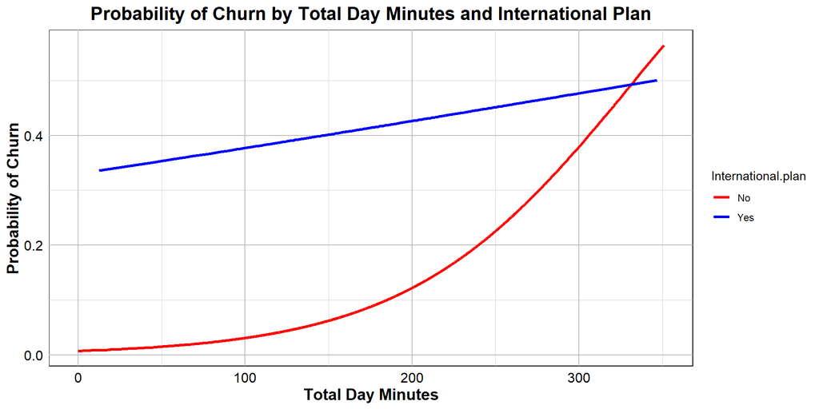

As a consequence, to address the imbalance and improve model accuracy, it is essential to consider training the model on a balanced dataset, ensuring that the model captures the true effect of predictors on churn, providing more reliable predictions.

```r
set.seed(1)
model_international_minutes_oversample = glm(Churn ~ Total.day.minutes * International.plan,
                                              family = binomial(link = "logit"),
                                              data = train_data_oversample)
```

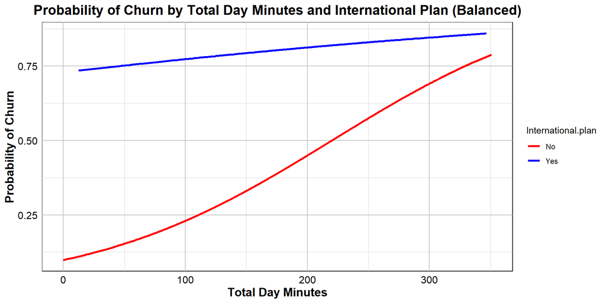

#### Effects of Customer Service Calls on Churn

his analysis aims to evaluate the impact of ‘Customer Service Calls’ on customer churn using logistic regression models. Given that probabilities are underestimated with an imbalanced dataset, we will only consider the oversampled dataset for this evaluation. The analysis of the imbalanced dataset is still available in the reference R script and revealed the same results as before.

Hence, we build the model using only customer service calls and we plot the computed probabilities.

```r
set.seed(1)
model_customer_service_calls_oversample = glm(Churn ~ Customer.service.calls,
                                             family = binomial(link = "logit"),
                                             data = train_data_oversample)
```

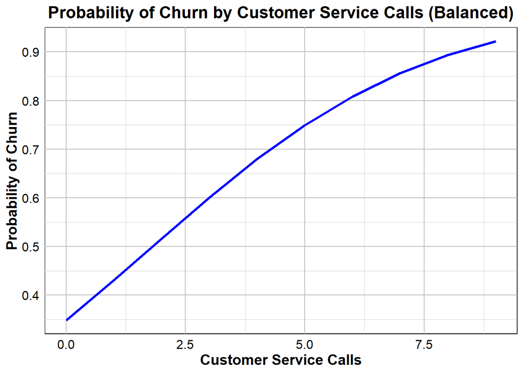

Again, the model confirms our findings during the EDA process. The plot demonstrates a strong positive relationship between the number of customer service calls and the probability of churn, highlighting the importance of effective customer service. The relationship is however quite trivial: frequent interactions with customer service often indicate that the customer is experiencing recurring issues or dissatisfaction with the service. The more frequently a customer contacts customer service, the more likely they are to be facing unresolved problems, leading to frustration and a higher likelihood of churn.

#### Classification tree

To provide a more concrete interpretation of our findings, we decided to implement a small but highly interpretable classification tree. This model is ideal for performing a clear analysis as it allows us to easily visualize and understand the decision paths and key factors influencing customer churn. The simplicity and transparency of a classification tree make it an excellent choice for communicating insights and actionable recommendations based on our data.

```r
set.seed(1)
simple_tree_oversample = rpart(Churn ~ Total.day.minutes + International.plan + Customer.service.calls,
                               data = train_data_oversample,
                               method = "class")
```

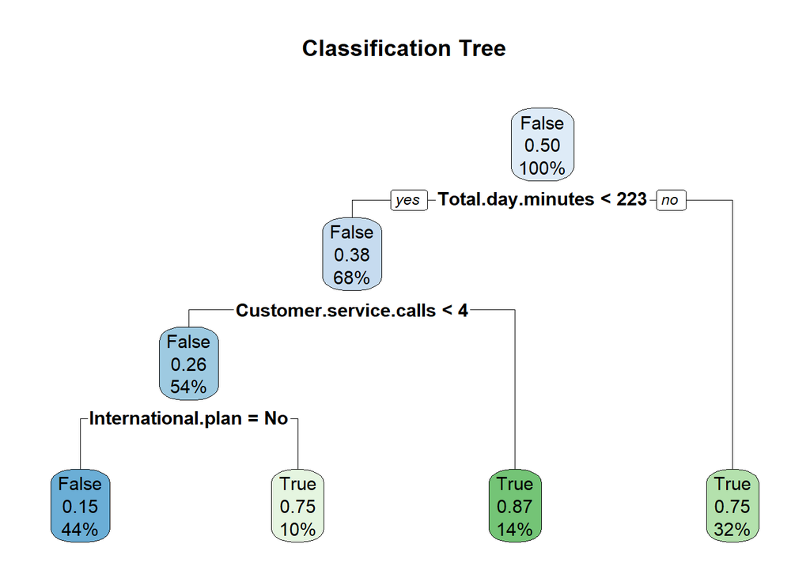

The classification tree shows that customers with high total day minutes (>= 223) (32% in the balanced dataset) have a 75% probability of churn. For customers with fewer total day minutes (< 223), churn probability is influenced by customer service calls and the presence of an international plan. Those with less than 4 customer service calls and no international plan (44% of the observations) have a low churn probability (15%), whereas having an international plan in this group (10%) increases the churn probability to 75%. Additionally, customers with 4 or more customer service calls have the highest churn probability (87%), confirming again the relevance of this factor on customer retention.

### BEST MODEL SELECTION

In this section, we explore various models and techniques in order to train the best possible model with the goal to predict consumer churn. Since in general the oversampled dataset provided better performances, we are going to consider only the latter, except for cases in which certain results are particularly relevant.

#### Linear Models

In this section, we focus on building linear models to predict customer churn. In spite of the fact that the performance is highly affected by the linearity assumption, those remain fundamental since they serves as a benchmark for more complex models and helps validate the data and approach. Subsequently, we perform variable selection, a crucial step in building efficient and interpretable models. It involves identifying the most relevant predictors from a set of potential variables. Two commonly used criteria for model selection are the Akaike Information Criterion (AIC) and the Bayesian Information Criterion (BIC).

##### Logistic Regression

In the first place, we consider as baseline the models in which no variable is used and all variables are included. Firstly, we build the model with all the variables.

```r
set.seed(1)
model_baseline_logistic_oversample = glm(Churn ~ .,
                              data = train_data_scaled_oversample,
                              family = "binomial")
```

Then, we consider the model without any variable:

```r
model_0 = glm(Churn ~ 1,
                   family = "binomial",
                   data = train_data_scaled_oversample)
```

And subsequently we test the hypothesis of equivalence between the two models

```r
anova(model_0, model_baseline_logistic_oversample, test = "Chisq")
```

```
## Analysis of Deviance Table
##
## Model 1: Churn ~ 1
## Model 2: Churn ~ Account.length + Area.code + International.plan + Voice.mail.plan +
##     Number.vmail.messages + Total.day.minutes + Total.day.calls +
##     Total.eve.minutes + Total.eve.calls + Total.night.minutes +
##     Total.night.calls + Total.intl.minutes + Total.intl.calls +
##     Customer.service.calls + Region
##   Resid. Df Resid. Dev Df Deviance  Pr(>Chi)
## 1      4259     5905.6
## 2      4241     4437.3 18   1468.3 < 2.2e-16 ***
## ---
## Signif. codes:  0 '***' 0.001 '**' 0.01 '*' 0.05 '.' 0.1 ' ' 1
```

The null model fits the data poorly with a deviance of 5905.6. The full model, which includes all the specified predictors, fits the data significantly better, with a deviance of 4437.3. The reduction in deviance (1468.3) is highly significant, with a p-value < 2.2e-16. Including the predictors in Model 2 significantly improves the fit of the model, indicating that the predictors collectively provide valuable information in predicting customer churn.

##### AIC

The AIC metric is used to compare models built with different set of predictors, with a focus on finding the model that best balances fit and complexity. It penalizes the number of parameters, discouraging overfitting, while prioritizing models with a better fit to the data. We performed feature selection using three different methods: forward selection, backward selection, and both directions selection.

```
## With forward selection 9 features have been selected.
```

```
## [1] "Total.day.minutes, Customer.service.calls, International.planYes, Voice.mail.planYes, Total.eve.minutes, Total.night.minutes, Total.intl.minutes, Total.intl.calls, Total.day.calls"
```

```
## With backward selection 16 features have been selected
```

```
## [1] "Area.code415, Area.code510, International.planYes, Voice.mail.planYes, Number.vmail.messages, Total.day.minutes, Total.day.calls, Total.eve.minutes, Total.eve.calls, Total.night.minutes, Total.intl.minutes, Total.intl.calls, Customer.service.calls, RegionNortheast, RegionSouth, RegionWest"
```

```
## With both directions selection 16 features have been selected
```

```
## [1] "Area.code415, Area.code510, International.planYes, Voice.mail.planYes, Number.vmail.messages, Total.day.minutes, Total.day.calls, Total.eve.minutes, Total.eve.calls, Total.night.minutes, Total.intl.minutes, Total.intl.calls, Customer.service.calls, RegionNortheast, RegionSouth, RegionWest"
```

Given the goal of creating a simpler model to avoid overfitting and enhance interpretability, we will choose the model generated by forward selection. This model includes only 9 features, providing a balance between simplicity and predictive power.

##### BIC

BIC is similar to AIC but applies a stronger penalty for the number of parameters. It is particularly useful for selecting simpler models, as it penalizes model complexity more heavily than AIC.

```
## With forward selection (BIC) 7 features have been selected.
```

```
## [1] "Total.day.minutes, Customer.service.calls, International.planYes, Voice.mail.planYes, Total.eve.minutes, Total.night.minutes, Total.intl.minutes"
```

```
## With backward selection (BIC) 13 features have been selected
```

```
## [1] "International.planYes, Voice.mail.planYes, Number.vmail.messages, Total.day.minutes, Total.day.calls, Total.eve.minutes, Total.eve.calls, Total.night.minutes, Total.intl.minutes, Customer.service.calls, RegionNortheast, RegionSouth, RegionWest"
```

```
## With both directions selection (BIC) 13 features have been selected
```

```
## [1] "International.planYes, Voice.mail.planYes, Number.vmail.messages, Total.day.minutes, Total.day.calls, Total.eve.minutes, Total.eve.calls, Total.night.minutes, Total.intl.minutes, Customer.service.calls, RegionNortheast, RegionSouth, RegionWest"
```

Again, the simplest model (the one with the lowest number of covariates) should be selected. In this case, with forward selection BIC selected 7 features confirming that it applies a stronger penalty for model complexity, often leading to simpler models.

In general, the process of feature selection confirmed that the variables International Plan, Total day minutes and Customer Service calls are relevant in order to predict customer Churn. Also, considering the stricter model we discover that the Region (State) categorical variable is not taken into account, while Voice mail plan, Total eve minutes, Total night minutes and Total intl minutes are kept in the model. The same features are selected by AIC that also considers Total intl calls and Total day calls.

##### Comparisson between Linear models

First, we report the confusion matrix for each of the three previously trained models to provide a general understanding of their performance. It is important to note that each prediction was made on the test set, which had been scaled using the parameters derived from the training set.

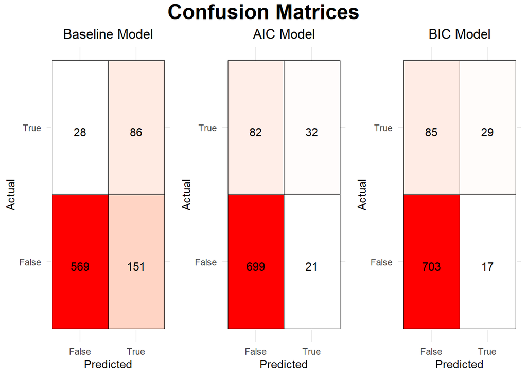

The Baseline Model has a surprisingly high number of true positives relative to the total actual positives, indicating it is particularly effective at minimizing false negatives. However, this effectiveness comes at the cost of a high number of false positives, as the model tends to classify many observations as positive. While this aligns with our aim of minimizing false negatives, the overall accuracy of the model is too low, indicating significant room for improvement. In contrast, the BIC and AIC models reduce misclassification errors but perform poorly in identifying true positives. This may be due to the models’ excessive simplicity, which fails to capture certain patterns in the test data. The similarity in the features selected by the BIC and AIC models is evidenced by their almost identical correlation matrices.

Also, we consider their performance in terms of AUC (Area Under ROC Curve). The ROC (Receiver Operating Characteristic) curve is a graphical representation of a classifier’s performance, plotting the true positive rate against the false positive rate at various threshold settings.

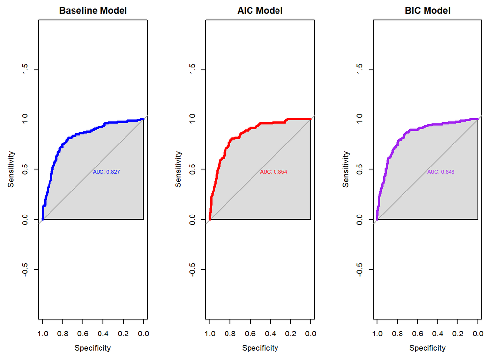

#### Penalized approaches

Penalized approaches like Lasso (Least Absolute Shrinkage and Selection Operator) and Ridge regression add regularization terms to the loss function to prevent overfitting. We decided to test these methods since AIC and BIC models showed minimal improvement with respect to the baseline model and hence a regularization approach could have enhanced model performance by managing complexity and selecting relevant features more effectively.

##### Lasso Regression

Lasso regression adds a penalty equal to the absolute value of the coefficients, encouraging sparsity by shrinking some coefficients to zero, effectively selecting only the most important predictors. This helps in building simpler and more interpretable models.

We start by training the model.

Afterwards, we consider the relation between the coefficients and the parameter lambda.

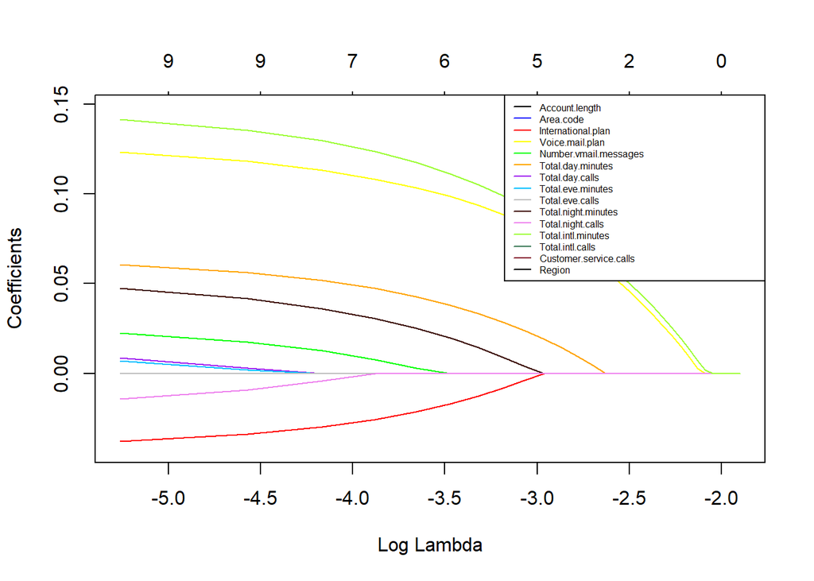

After the preliminary analysis, we perform the crucial step of hyperparameter tuning to identify, with cross validation, an estimate for the best value for lamda.

```r
set.seed(1)
# Train the Lasso regression model on the oversampled data with tuning
model_lasso_oversample = train(Churn ~ .,
                               data = train_data_scaled_oversample,
                               method = "glmnet",
                               metric = "Accuracy",
                               trControl = trainControl(method = "cv", number = 10),
                               tuneGrid = expand.grid(alpha = 1, lambda = seq(0, 0.15, length = 30)))
```

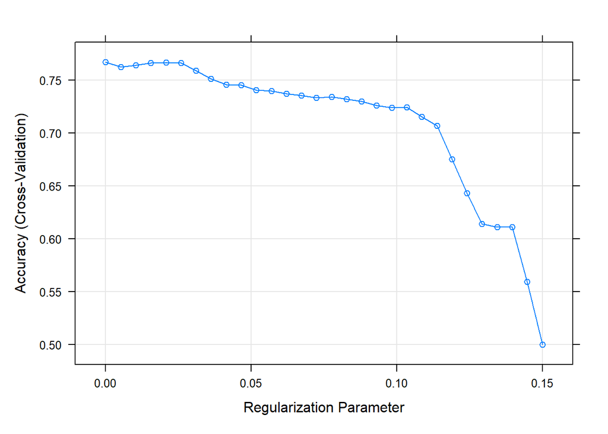

```
## The highest value of accuracy: 0.7673709 is obtained with lambda = 0
```

##### Ridge Regression

Ridge regression is another linear regression technique that includes a penalty term to reduce model complexity and prevent overfitting. Unlike Lasso regression, which can shrink some coefficients to zero and perform feature selection, with Ridge the coefficients tend to zero but they are never exactly to zero.

As we have done before, we firstly train the model to have an overview of the relation between the parameter lambda and the coefficients.

```r
set.seed(1)
ridge_fit_oversample = glmnet(x = X_train_oversample,
                              y = Y_train_oversample,
                              alpha = 0)
```

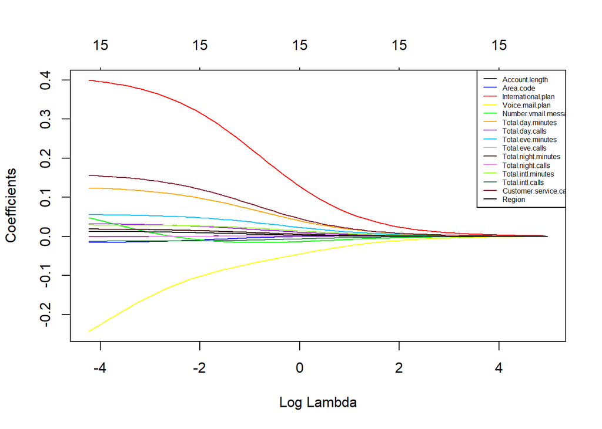

The plot confirms the earlier statement: as the parameter Lambda increases, the coefficients shrink towards zero but never actually reach it, in contrast with what we have previously shown with Lasso.

We then proceed, as we have done for Lasso regression, to tune the parameters selecting the value with which the model reaches the highest accuracy on the validation set.

```r
set.seed(1)
model_ridge_oversample = train(Churn ~ .,
                               data = train_data_scaled_oversample,
                               method = "glmnet",
                               metric = "Accuracy",
                               trControl = trainControl(method = "cv", number = 10),
                               tuneGrid = expand.grid(alpha = 0, lambda = seq(0, 0.15, length = 30)))
```

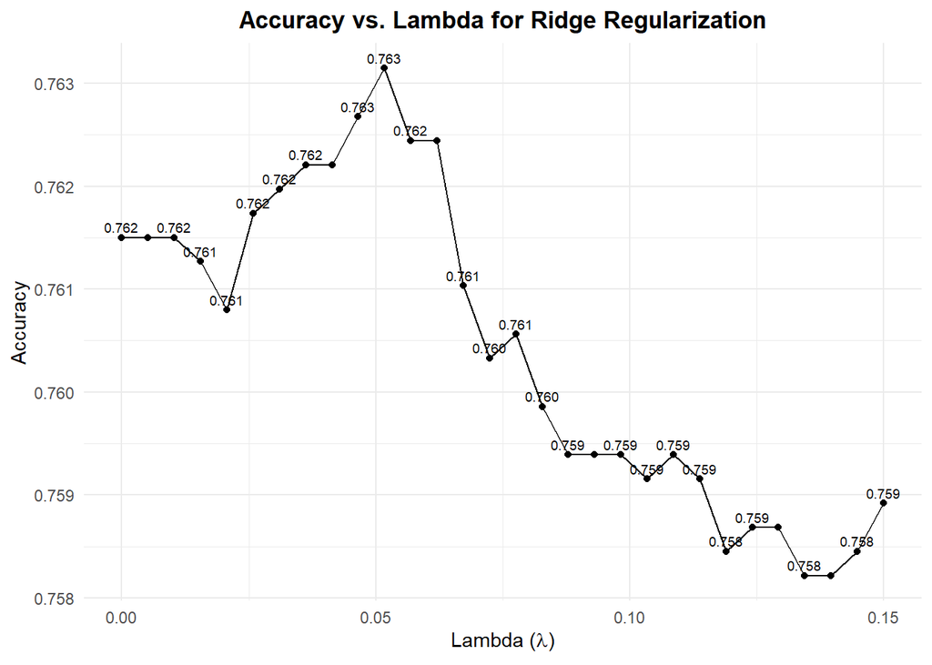

```
## The highest accuracy is: 0.7631455 with parameter lambda = 0.05172414
```

##### Comparisson between penalized approaches

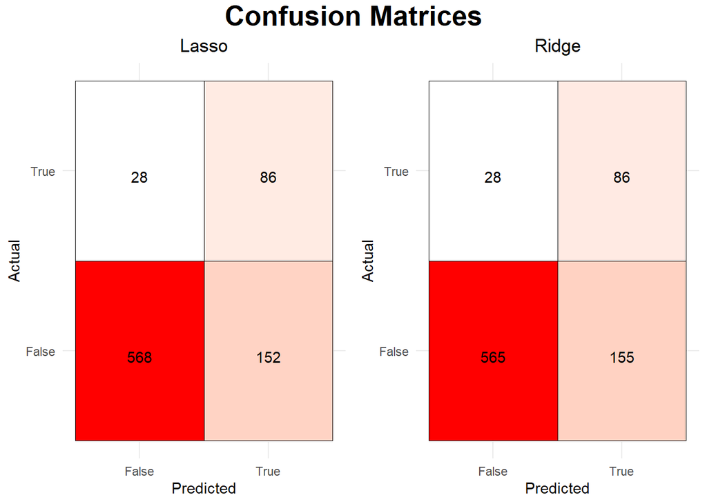

The similarity between the confusion matrices for the penalized approaches (Lasso and Ridge) and the baseline model indicates that the lambda parameter has little impact on the results. In the case of Lasso, the lambda value is almost negligible, and for Ridge, it is particularly small. This confirms that removing and shrinking features does not benefit our analysis. Consequently, these three methods essentially represent the same model, leading us to decide not to report the AUC curves for the penalized approaches. Including them in our final conclusions would be redundant, as the findings would merely reiterate what has already been discussed regarding the baseline model’s performance.

#### Non linear methods

While linear and penalized regression methods provide a solid foundation for understanding the relationships between predictors and the response variable, they often fall short when dealing with more complex, non-linear interactions within the data. To address this, we turn to non-linear methods which can capture intricate patterns and improve predictive performance. Non-linear models, such as the decision tree seen before, random forests, and boosting techniques, offer flexibility in modeling relationships that linear methods cannot adequately describe.

##### Random Forests

With Random Forests, a number of decision trees is built on bootstrapped training samples. However, each time a split in a tree is considered, a random sample of m predictors is chosen as split candidates from the full set of predictors.

We first start by building a simple model with default parameters. The number of predictors considered at each split (mtry in the code) is typically the square root of the number of the predictors. In our case is then 4. We also consider a forest with 500 trees.

```r
set.seed(1)
random_forest_model_oversample = randomForest(Churn ~ ., data = train_data_oversample,
                                              mtry = 4,
                                              ntree = 500,
                                              importance = T)
```

In this initial analysis, our primary focus is not on model performance but on observing how the Out-Of-Bag (OOB) error changes as we increase the number of trees.

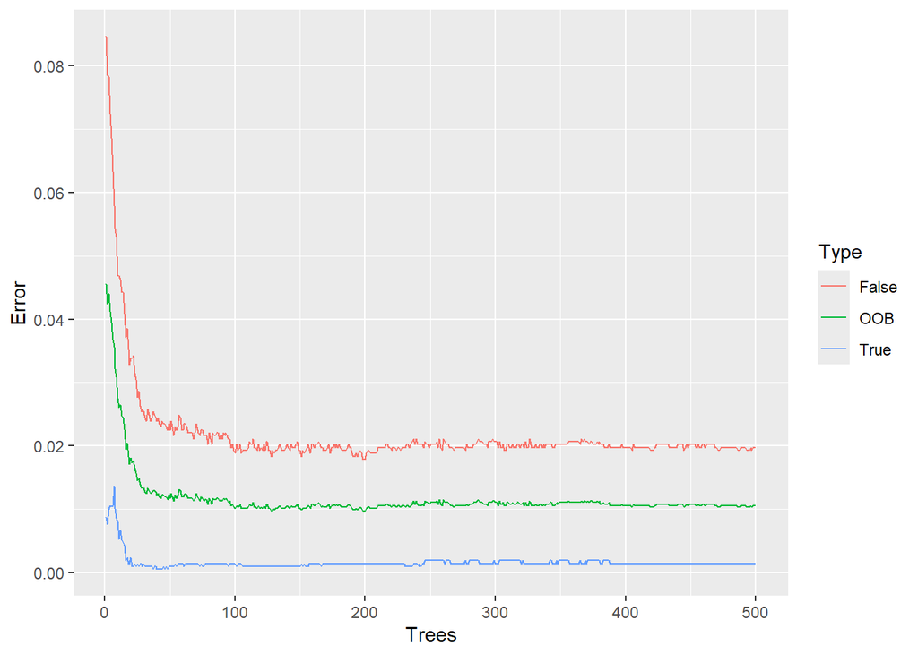

We can see that the out-of-bag (OOB) error stabilizes after around 100 trees, indicating that the random forest model achieves consistent performance. The error for the “True” class is significantly lower than the “False” class, suggesting the model is better at predicting “True” than “False”. This could be caused by the fact that we are training the model on an oversampled balanced data. However, we also tested the model on unbalanced data and its performance was significantly worse.

We can also show the features importance considering the metric of mean decrease accuracy (computed by measuring the increase in the model’s OOB error when a feature’s values are randomly permuted; higher decreases in accuracy indicate greater importance).

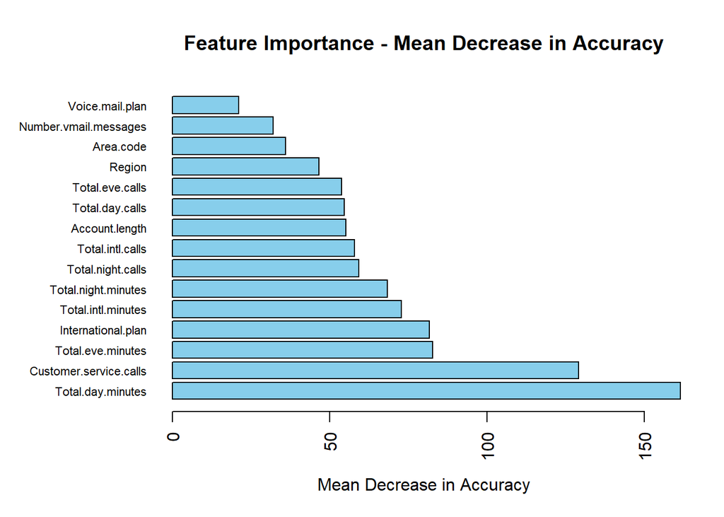

One of the most straightforward drawbacks of random forests is their tendency to overfit the data due to the inherent nature of decision trees, which are particularly prone to overfitting. Although random forests mitigate this issue by increasing model variability, hyperparameter tuning is essential for optimal performance.

In our R reference code, we employed two different strategies to tune the parameters. First, we used a classic approach with the “train” function, specifying a tune grid to test with 5-fold cross-validation. However, this function automatically tunes only the parameter mtry and does not consider other relevant parameters such as the number of trees, maximum number of nodes, and node size. Therefore, we built a grid, randomly sampled combinations, and tested them using the OOB error, which is an accurate estimate of the test error. Since this approach yielded better results, we decided to report it.

Best Parameters for Random Forest

| n_tree | m_try | max_nodes | node_size | mean_err_rate |
| --- | --- | --- | --- | --- |
| 600 | 6 | 200 | 1 | 0.012027 |

Once we have found our tuned hyperparameters, we use them in order to build the model that will be used in order for us to predict Customer Churn.

```r
# Train the final model with the best parameters
final_rf_model <- randomForest(
  Churn ~ .,
  data = train_data_oversample,
  ntree = best_parameters_random_forest$n_tree,
  mtry = best_parameters_random_forest$m_try,
  nodesize = best_parameters_random_forest$node_size,
  maxnodes = best_parameters_random_forest$max_nodes,
  importance = TRUE
)
```

##### XGBOOST

XGBoosting is an advanced implementation of gradient boosting that builds an ensemble of decision trees sequentially, with each tree correcting the errors of the previous ones, optimized for speed and performance.

Since XGBoost requires numerical input and cannot directly handle categorical variables, as a first essential step we created dummy variables to encode categorical variables.

Then, in order to have a general understanding of the performance of the model, we trained it without tuning the hyperparameters.

```r
# In the first place we train the algorithm without tuning
set.seed(1)
model_xg = xgboost(as.matrix(X_train_oversample_dummy),
                   label = Y_train_oversample_dummy,
                 nrounds = 50,
                 objective = "binary:logistic",
                 eval_metric = "error")
```

To gain insight into the relevance of the ntreelimit parameter (and thereby the importance of tuning hyperparameters), we consider the error on the test set. It is important to note that this analysis is not part of the model training process but is merely an evaluation of the parameter, as models should not be trained on the test set.

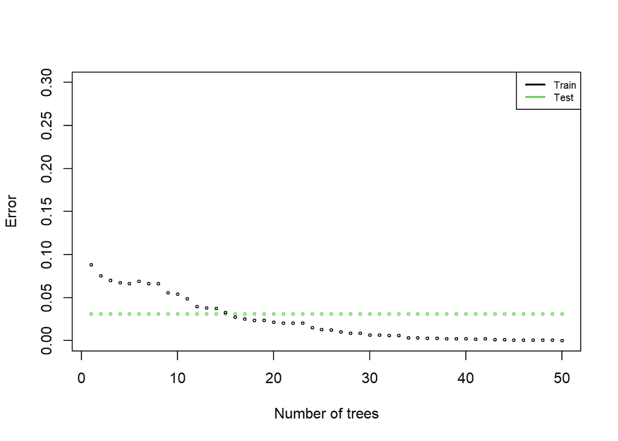

The plot shows that as the number of trees increases, the training error consistently decreases, approaching zero, indicating that the model fits the training data very well. However, the test error stabilizes at a low value early on and remains relatively constant, suggesting that additional trees do not significantly improve the model’s performance on the test data. This indicates that the model generalizes well without overfitting, as there is a minimal gap between the training and test errors after a certain number of trees.

We then proceed with the process of hyperparameter tuning using cross validation. Since tasks like cross-validation can be paralized, in order to speed up computations, we created a cluster of 5 worker nodes with the library doParallel.

```r
cl = makePSOCKcluster(5)
registerDoParallel(cl)
```

```r
set.seed(1)
model_xg_cv = train(
  Churn ~ ., data = train_data_oversample,
  method = "xgbTree",
  trControl = fitControl,
  verbose = FALSE,
  tuneGrid = tune_grid,
  objective = "binary:logistic",
  eval_metric = "error"
)
```

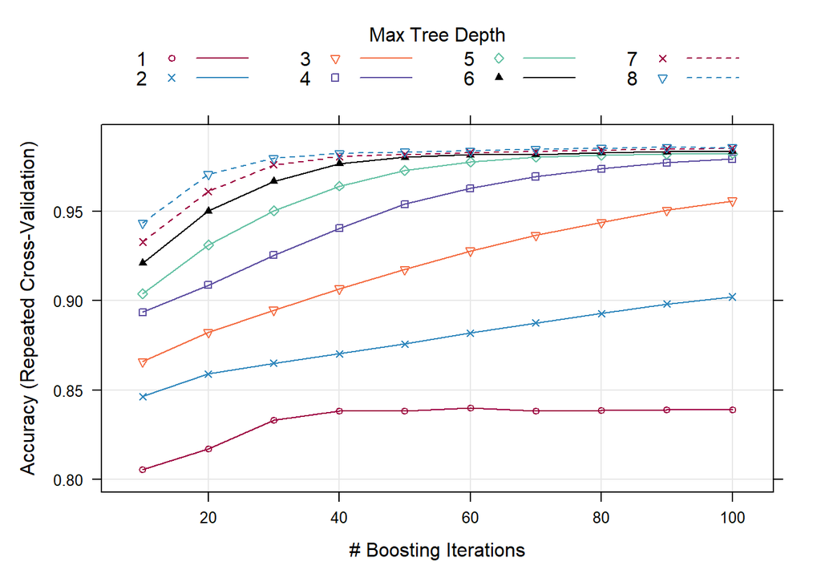

Best Parameters for XGBOOST

|  | nrounds | max_depth | eta | gamma | colsample_bytree | min_child_weight | subsample |
| --- | --- | --- | --- | --- | --- | --- | --- |
| 79 | 90 | 8 | 0.3 | 0 | 1 | 5 | 1 |

##### Comparisson between Tree based models

As we have done before, to firstly asses the performances we plot the confusion matrices for Random Forests and XGBOOST (with and without tuning).

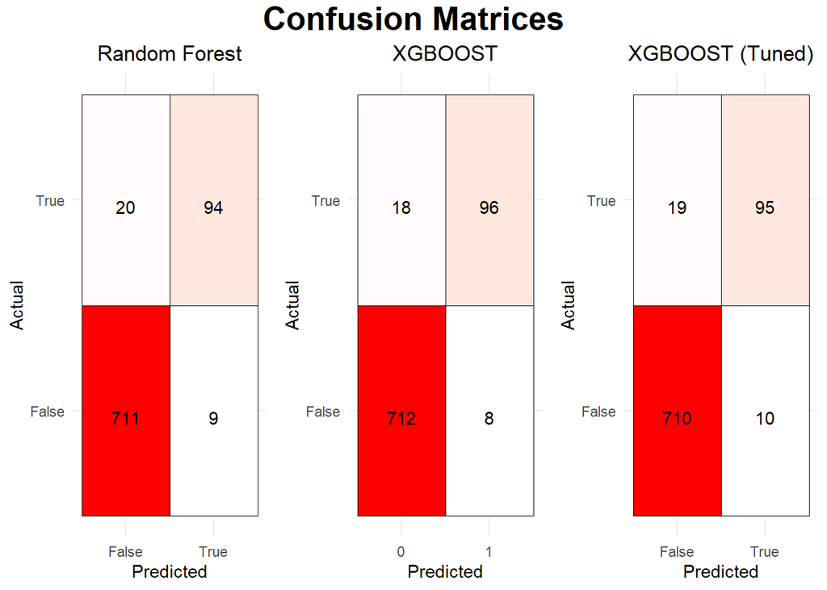

The initial belief that non-linear models would perform better is confirmed. The tree-based methods present similar confusion matrices, balancing sensitivity and specificity: indeed, the number of true positives is significantly higher than in the previous cases without any tradeoff in overall accuracy. Furthermore, the models excel at classifying the negative class, with very few misclassifications.

A peculiar result is that the untuned model seems to perform better than the tuned model. However, since the difference between the two is only three observations, this is likely due to the way the test and train sets were split. It would be inaccurate to conclude definitively that the untuned model is better, but also that this result is purely by chance. Indeed, it is possible that better hyperparameter tuning (requiring higher computational power) is needed or that the cross-validation error did not provide an accurate estimate of the test error.

The substantial increase in performance is confirmed also by the AUC metrics:

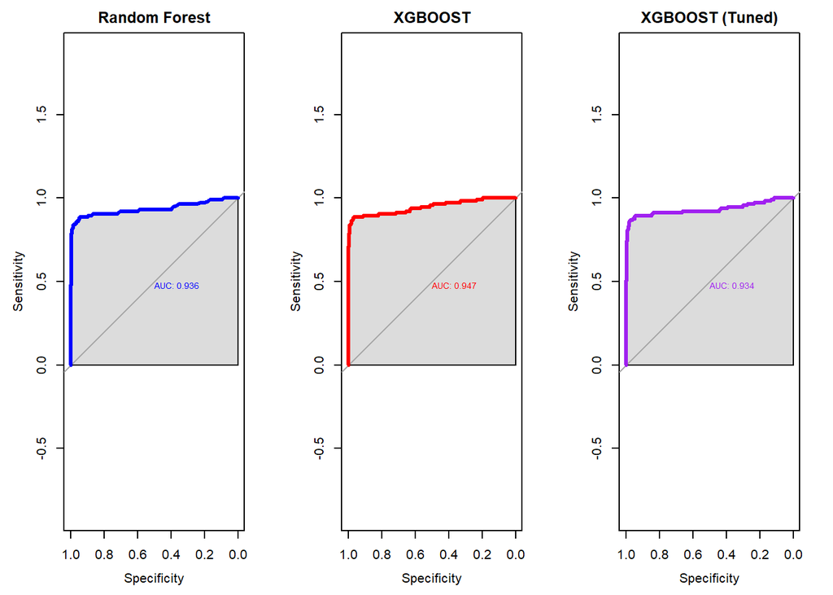

### CONCLUSIONS

Given the high imbalance in our dataset, we have prioritized sensitivity in our selection criteria because minimizing false negatives and thereby reducing missed positives is crucial for our analysis. In the telecom industry, failing to predict a customer’s churn (false negative) is more costly than predicting that a customer will churn when they won’t (false positive). This approach helps ensure we capture as many potential churners as possible, enabling proactive retention efforts and ultimately reducing customer attrition. However, balancing sensitivity with accuracy remains important: if there are too many false positives because the models tend to classify most observations as positive, proactive retention efforts may become too costly and often unnecessary. Therefore, while sensitivity (recall) is our primary focus to mitigate the higher cost of missed churn predictions, the overall accuracy must also be satisfactory to ensure a feasible and effective retention strategy.

[output not shown]

Considering our initial goal of minimizing false negatives, the best model appears to be the XGBOOST with default parameters. However, given the minimal difference in performance, if we were to predict customer churn on unobserved data, we believe the tuned XGBOOST model has the highest probability of delivering the best performance. This is because the results on the test set can be heavily influenced by the specific nature of the observations, and changing the random seed could lead to different outcomes. Nonetheless, hyperparameter tuning remains a crucial technique that must be applied to tailor the model to the specific problem we are addressing.

Overall, we are satisfied with the performance of the non-linear methods, as evidenced by their balanced sensitivity and specificity. The high overall accuracy is further supported by elevated F1 scores, which require both high recall (sensitivity) and precision. These metrics demonstrate that our models are not only accurate but also effective at identifying true positives and minimizing false positives, making them robust choices for predicting customer churn.

## TASK 2

For this task, we provided a customer segmentation which is based on the CLV index (Customer Lifetime Value) and provides insights about groups of customers that the company can target with ad-hoc promotional campaigns. In this way the company would be more efficient in targeting only customers who have a large CLV.

### CLV Computation and Distribution

Since our dataset did not include relevant features that could have been used for an insightful interpretation (since the dataset is mainly provided in order to train models to predict customer churn) we decided to aproximate the CLV. Customer Lifetime Value (CLV) is vital for predicting revenue, allocating resources efficiently, and segmenting customers for targeted marketing. It helps manage acquisition costs by ensuring they do not exceed the customer’s lifetime value and supports strategic decision-making in product development, pricing, and customer relationship management.

#### Computing CLV

In the first place, we computed “Total charge” in order to estimate the revenue for each customer. The average customer lifespan is another important metric needed to compute the CLV. We decided to compute it based on the assumption that if a fraction of customers churn each period, then, on average, a customer will stay for 1/churn rate periods. A lower Churn Rate indicates indeed an higher Customer Lifespan. We then proceeded by computing (approximating) the CLV as the product between the Total Charges for each customer and the average customer lifetime span. Ultimately, we calculated the total daily minutes as an additional “summary” metric representing the time a customer spends using the service each day. The creation of this index serves to enhance and expand our set of features for clustering analysis. By including total daily minutes, we aim to capture a more comprehensive picture of customer behavior, allowing for more accurate and insightful clustering results.

```r
Data$Total.charge = Data$Total.day.charge + Data$Total.eve.charge +
  Data$Total.night.charge + Data$Total.intl.charge #Total Charge

churn_rate = mean(Data$Churn == "True") # Churn Rate
retention_rate = 1 - churn_rate #Customer Retention Rate.
avg_customer_lifespan = 1 / churn_rate #AVG Customer Lifetime span

Data$CLV = Data$Total.charge * avg_customer_lifespan

Data$Total.minutes = Data$Total.day.minutes + Data$Total.eve.minutes +
  Data$Total.night.minutes + Data$Total.intl.minutes #Total Minutes
```

#### CLV Distribution

Now that we have computed the CLV index, which is basically a summary of the various charges paid by each customer, we analyze it like we did for the other features in the EDA to gain insight about its distribution and its relation with some other features.

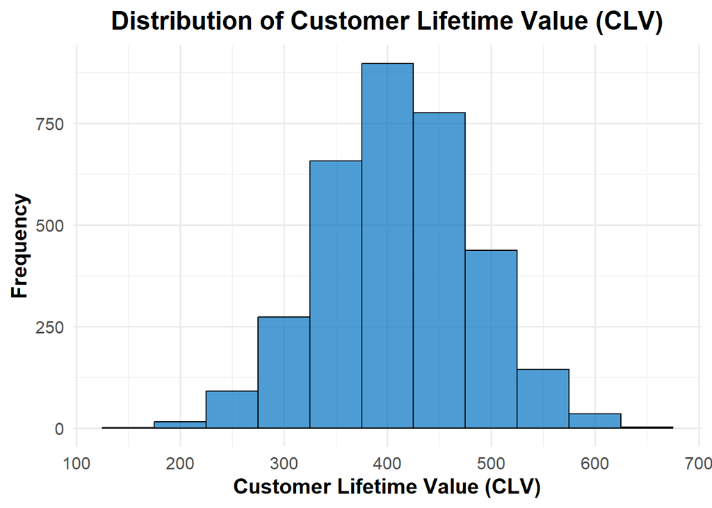

The histogram shows that most customers have a Customer Lifetime Value (CLV) centered around 400 units, with the majority of values falling between 300 and 500. The distribution is slightly left-skewed, indicating some customers have significantly lower CLV. This central tendency suggests a typical customer profile, while the skew highlights opportunities for targeted retention strategies. Overall, the distribution provides insights for optimizing customer value and retention efforts.

##### CLV by Top Ten States

Considering the dataset, understand if the CLV were distributed differently along states is an essential analysis to perform.

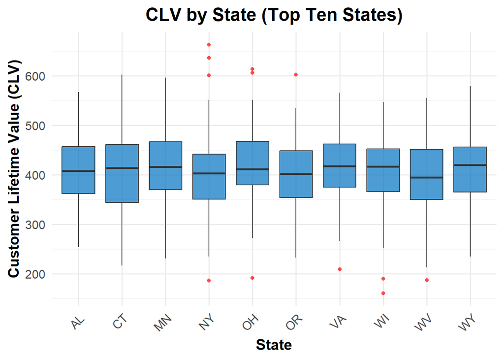

In general, the median CLV values are relatively similar across the states, indicating a consistent customer value distribution. However, some states exhibit greater variability, as evidenced by wider IQRs and more outliers.

### CLUSTERING ALGORITHMS

In this section, we develop clustering algorithms to analyze customer segments. We will explore two clustering techniques: K-means and Hierarchical clustering. For this analysis, we focus on the features Account Length, Total Minutes, and Customer Lifetime Value (CLV). These features are selected because they are highly representative and particularly relevant for our objective of understanding customer behavior and optimizing retention strategies. By leveraging these clustering techniques, we aim to identify distinct customer groups that can inform targeted marketing and retention efforts. Also, a crucial step is to perform scaling on the dataset.

```r
# Selection and normalization of the features
clustering_data = Data[, c("Account.length", "CLV", "Total.minutes")]
clustering_data_scaled = scale(clustering_data)
```

#### K-Means

Firstly, we tried to segment customers with K-means clustering, a popular and efficient method for partitioning a dataset into distinct groups or clusters. K-means clustering aims to minimize the variance within each cluster, thereby maximizing the homogeneity of data points within clusters and the heterogeneity between clusters.

##### Identification of optimal number of clusters

We determined the optimal number of clusters using both the elbow method and the silhouette method. The elbow method identified the point where the within-cluster sum of squares (WSS) sharply decreases, indicating the optimal balance between model complexity and accuracy. The silhouette method measured how well data points fit within their assigned clusters compared to others. By comparing both methods, we ensured a robust and well-defined clustering solution.

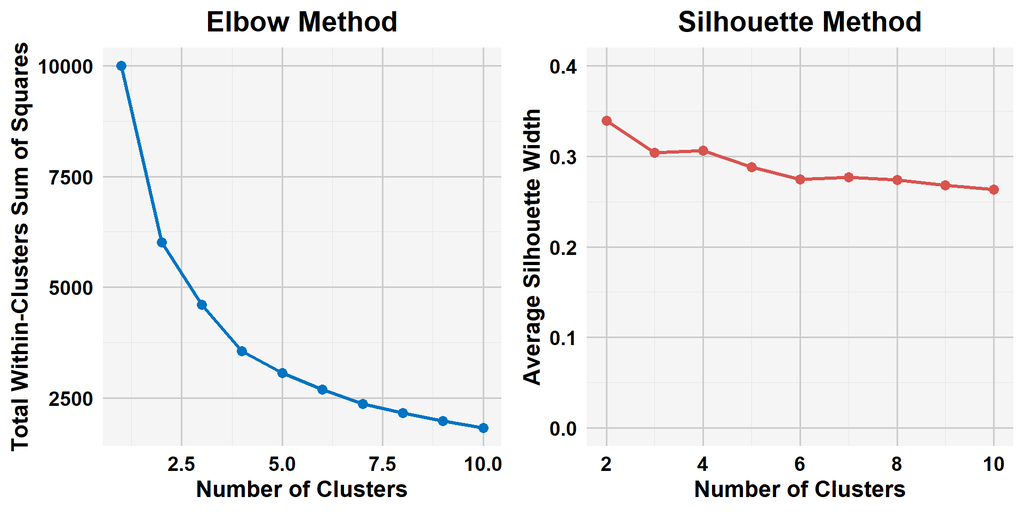

The Elbow Method plot shows the within-cluster sum of squares (WSS) against the number of clusters. As the number of clusters increases, the WSS decreases, indicating improved cluster compactness. The elbow point, where the rate of decrease sharply slows, suggests 2 clusters as an optimal balance between model complexity and accuracy. The Silhouette Method plot displays the average silhouette width against the number of clusters. The highest silhouette width is also observed at 2 clusters, indicating the best fit and most distinct cluster separation at this point.

Although both methods indicate that 2 clusters are optimal, we chose to select 3 clusters. At 3 clusters, the WSS value is further minimized, and we are not overly concerned about overfitting. Additionally, selecting 3 clusters provides a more flexible and explorative framework, allowing us to uncover hidden patterns and structures in the data. This approach helps us identify distinct customer segments and gain a deeper understanding of the data.

##### K-Means in action

Once we have found the optimal value for k, it is possible to apply the k-means algorithm in order to to actually find and visualize customer segments (with dimensionality reduction).

```r
# Apply K-means clustering with the chosen number of clusters
set.seed(1)
kmeans_result = kmeans(clustering_data_scaled, centers = 3, nstart = 25)
```

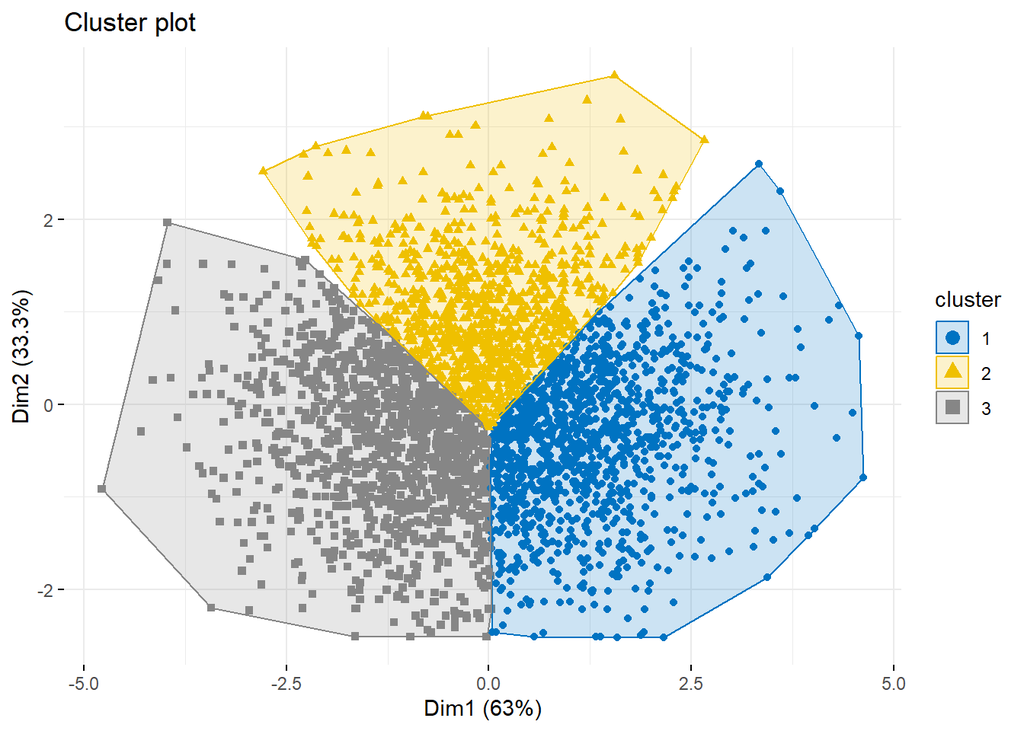

#### Hierarchical Clustering

Hierarchical clustering builds a hierarchy of clusters without needing to pre-specify the number of clusters. It can be agglomerative (bottom-up), starting with individual observations and merging them, or divisive (top-down), starting with one cluster and splitting it.

##### Different linkages methods analysis

In this section, we perform hierarchical clustering on our dataset. To identify the best linkage method and the optimal number of clusters (k), we computed silhouette width values for various combinations. We consider the following linkage methods: Ward.D2, complete, average, single, and centroid linkage. For k, we test a range of values between 2 and 4, as these provided the best results in our preliminary analysis.

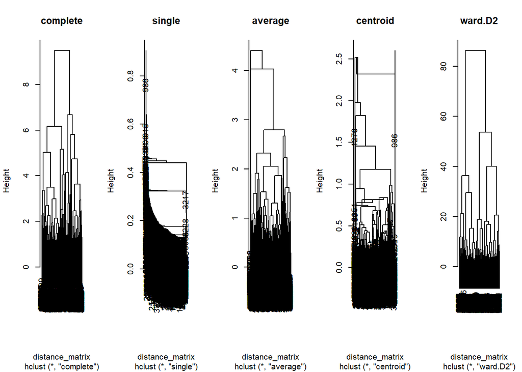

The results of hierarchical clustering are depicted in the dendrograms. Each horizontal line represents the merging or splitting of clusters at various levels of the hierarchy, with the height of the line indicating the distance or dissimilarity between the clusters when they are joined. Complete Linkage offers balanced cluster compactness, while Single Linkage is prone to elongated clusters and noise sensitivity. Average Linkage produces more natural clusters, and Centroid Linkage shows size variations influenced by outliers. Ward’s Method forms compact, well-defined clusters, minimizing within-cluster variance, and is the most robust method.

Silhouette width with different k and linkages methods

| Method | K | Silhouette_Width |
| --- | --- | --- |
| complete | 2 | 0.3138570 |
| complete | 3 | 0.2500605 |
| complete | 4 | 0.2120162 |
| single | 2 | 0.5238035 |
| single | 3 | 0.4626141 |
| single | 4 | 0.3025137 |
| average | 2 | 0.4622350 |
| average | 3 | 0.2993083 |
| average | 4 | 0.2186155 |
| centroid | 2 | 0.4669284 |
| centroid | 3 | 0.4117482 |
| centroid | 4 | 0.2922083 |
| ward.D2 | 2 | 0.3168434 |
| ward.D2 | 3 | 0.2770761 |
| ward.D2 | 4 | 0.2564237 |

The table indicates that 2 clusters provide the highest result across all clustering methods, with single linkage achieving the highest silhouette width (0.5238) for K=2. However, single linkage often results in less compact clusters. Centroid and average linkage also perform well with reasonably high silhouette widths, suggesting they may offer more compact and well-defined clusters. In summary, 2 clusters are optimal, and while single linkage performs best, centroid and average linkage methods may be preferable for more cohesive clusters. However, since we aim to build a model that balances compactness and natural data representation Ward.D2 with k = 3 seems the best choice (in particular if we consider the dendogram) even if it has a lower silhouette width. Indeed, it creates very compact clusters and is often considered robust for many clustering tasks.

##### Hierarchical clustering in action

In order to have a more accurate representation of the segmentation, we report the dendogram cutting it at early stages so that it is more readable.

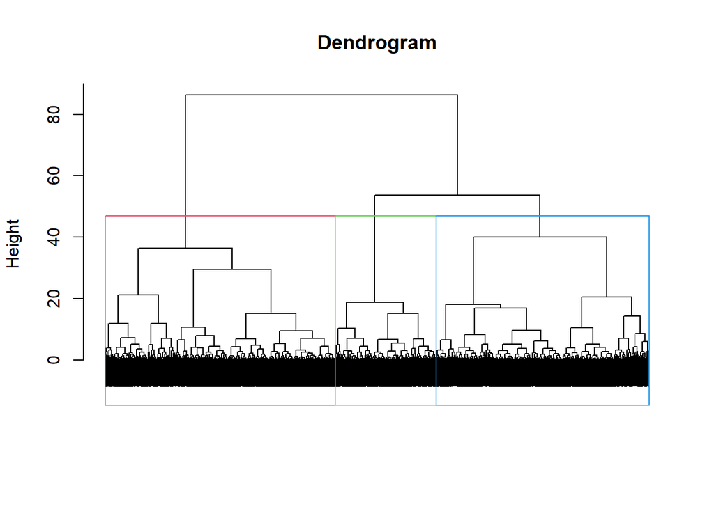

Subsequently, we visualize the segments in a lower dimensional space:

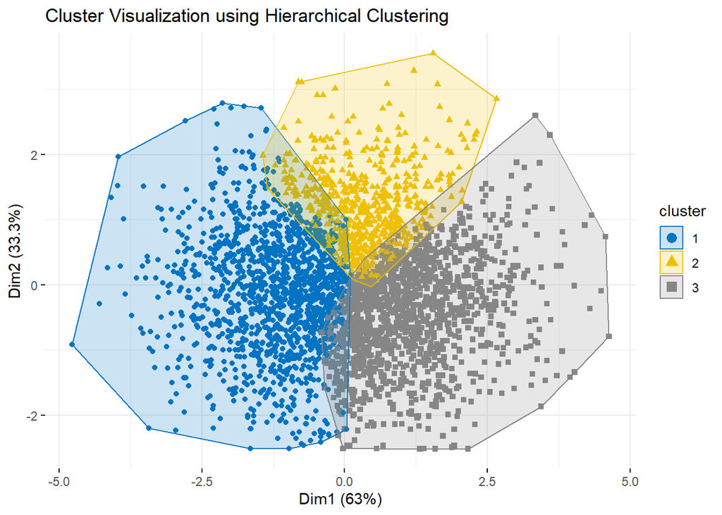

It is clear that the clusters are similar to the ones that we have found with k-mean algorithm. However, in this case there are noticeable overlaps between different clusters, indicating that some customer segments share similar characteristics. This overlap suggests that while hierarchical clustering has identified distinct groups, the boundaries between some clusters are not entirely clear-cut, reflecting the complexity and potential similarities within the dataset.